# 1 - Un pipeline básico con `targets`

## Workflow básico de `targets`

Un workflow que hace uso de `targets` incluye un archivo principal llamado `_targets.R`.

Este archivo contiene la definición del pipeline de análisis de datos, que consiste en una serie de “targets” u objetivos. Cada target representa un paso en el análisis y cada uno de estos pasos está asociado con una función.

### Nuestro primer archivo `_targets.R`

El paquete `targets` proporciona una función llamada `tar_script()` que crea un archivo `_targets.R` que funciona como plantilla.

```r
library(targets)
tar_script()
```

Este es el contenido del archivo `_targets.R` generado automáticamente:

```r
library(targets)
# This is an example _targets.R file. Every
# {targets} pipeline needs one.
# Use tar_script() to create _targets.R and tar_edit()
# to open it again for editing.
# Then, run tar_make() to run the pipeline
# and tar_read(data_summary) to view the results.

# Define custom functions and other global objects.
# This is where you write source(\"R/functions.R\")
# if you keep your functions in external scripts.
summarize_data <- function(dataset) {
  colMeans(dataset)
}

# Set target-specific options such as packages:
# tar_option_set(packages = "utils") # nolint

# End this file with a list of target objects.
list(
  tar_target(data, data.frame(x = sample.int(100), y = sample.int(100))),
  tar_target(data_summary, summarize_data(data)) # Call your custom functions.
)
```

El archivo carga la librería y contiene una función llamada `summarize_data` que obtiene el promedio de cada columna en la variable `dataset`.

Al final define una lista de targets con la función `tar_target()`. En este caso, tenemos dos:

1. `data`: crea un data frame con dos columnas `x` y `y`, cada una con una permutación aleatoria de números enteros del 1 al 100.
2. `data_summary`: utiliza la función `summarize_data` para calcular el promedio de las columnas del data frame `data`.

### Modificando el archivo `_targets.R`

Vamos a utilizar el dataset [**Allrecipes**](https://github.com/rfordatascience/tidytuesday/blob/main/data/2025/2025-09-16/readme.md), que contiene información sobre recetas de cocina y fue el dataset de TidyTuesday de la semana 37 del 2025.

Realizaremos un análisis sencillo para obtener la cantidad de recetas por tipo de cocina, el tiempo de preparación y cocción promedio y el puntaje promedio en su calificación.

Siguiendo la documentación de github, podemos leer el dataset `cuisines.csv` directamente desde la URL del archivo CSV.

Nuestra limpieza de datos incluirá eliminar valores faltantes y la selección de columnas relevantes. Añadimos la lectura y limpieza de datos a nuestro archivo `_targets.R` de la siguientes manera:

```r
library(targets)
library(readr)
library(dplyr)

limpiar_datos <- function(data) {
  data |>
    filter(
      !is.na(total_ratings) &
        !is.na(avg_rating) &
        !is.na(total_time)
    ) |>
    select(name, country, total_time, avg_rating, total_ratings)
}

list(
  tar_target(
    recetas_raw,
    read_csv(
      "https://raw.githubusercontent.com/rfordatascience/tidytuesday/main/data/2025/2025-09-16/cuisines.csv"
    )
  ),
  tar_target(recetas, limpiar_datos(recetas_raw))
)
```

En esta primera versión de nuestro archivo `_targets.R`, hemos cargado todos los paquetes necesarios y definido una función `limpiar_datos()` para limpiar el dataset. Luego, hemos creado dos targets:

1. `recetas_raw`: el dataframe que resulta de utilizar `read_csv` del paquete `readr`.
2. `recetas`: el dataframe que resulta de aplicar la función `limpiar_datos()` al target anterior.

### Ejecutando el pipeline

Con el archivo `_targets.R` modificado, ejecutamos el pipeline con la función `tar_make()`. Esta función procesa todos los targets definidos en el archivo, respetando sus dependencias.

La salida de la ejecución se muestra en la consola e indica qué targets se están construyendo y cuáles ya están actualizados. Es similar a la siguiente:

```
+ recetas_raw dispatched
✔ recetas_raw completed [183ms, 280.57 kB]
+ recetas dispatched
✔ recetas completed [6ms, 35.00 kB]
✔ ended pipeline [311ms, 2 completed, 0 skipped]
```

**Intenta ejecutar el pipeline nuevamente. ¿Qué observas en la salida?**

```
✔ ended pipeline [51ms,  2 skipped]
```

`targets` detecta que no ha habido cambios en los targets y los marca como “skipped” (saltados), ya que no es necesario reconstruirlos. Así podemos asegurarnos de solo ejecutar los pasos que han cambiado, optimizando el tiempo de ejecución.

### Accediendo a los resultados

Ahora, ¿dónde están los objetos `recetas_raw` y `recetas` que hemos creado?

Después de ejecutar el pipeline, puedes notar que se ha creado una carpeta llamada `_targets/` en tu directorio de trabajo. Esta carpeta contiene todos los datos y resultados generados por el pipeline.

Para acceder a los objetos generados tenemos dos funciones principales:

- `tar_read()`: lee un target específico desde el almacenamiento de `targets`.
- `tar_load()`: carga un target específico en el entorno global de R.

Por ejemplo, para leer el objeto `recetas_raw` y ver sus primeras filas, podemos usar:

```r
tar_read(recetas_raw)
```

```
# A tibble: 2,218 × 17
   name     country url   author date_published ingredients calories   fat carbs
   <chr>    <chr>   <chr> <chr>  <date>         <chr>          <dbl> <dbl> <dbl>
 1 Saganak… Greek   http… John … 2024-02-07     1 (4 ounce…      391    25    15
 2 Coney I… Jewish  http… John … 2024-11-26     2 ¾ cups a…      301    17    31
 3 Diana's… Austra… http… CHIPP… 2022-07-14     1 ½ cups w…       64     3     9
 4 Chilean… Chilean http… Heidi  2025-01-31     ½ cup chop…      106     9     7
 5 Tex-Mex… Tex-Mex http… Ann    2025-02-18     2 cups all…      449    23    58
 6 Newfoun… Canadi… http… MomWh… 2022-08-12     1 (3 pound…      958    24   144
 7 Pasta e… Italian http… Buckw… 2023-12-12     1 cup dry …      378    10    59
 8 Danish … Danish  http… TheOt… 2020-06-19     4 cups all…       90     5    10
 9 Lemon P… Amish … http… Laura… 2025-01-21     2 cups all…      157     6    25
10 Pan con… Spanish http… Luis … 2025-06-02     1 large to…      322    16    39
# ℹ 2,208 more rows
# ℹ 8 more variables: protein <dbl>, avg_rating <dbl>, total_ratings <dbl>,
#   reviews <dbl>, prep_time <dbl>, cook_time <dbl>, total_time <dbl>,
#   servings <dbl>
```

Y para cargar el objeto `recetas` en nuestro entorno global, usamos:

```r
tar_load(recetas)
head(recetas)
```

```
# A tibble: 6 × 5
  name                            country    total_time avg_rating total_ratings
  <chr>                           <chr>           <dbl>      <dbl>         <dbl>
1 Saganaki (Flaming Greek Cheese) Greek              15        4.8            25
2 Coney Island Knishes            Jewish            180        4.6            10
3 Diana's Hawaiian Bread Rolls    Australia…        180        4.3           126
4 Chilean Pebre                   Chilean            10        5               1
5 Tex-Mex Sheet Cake              Tex-Mex            45        3.8            13
6 Newfoundland Jigg's Dinner      Canadian          675        4.4            40
```

### Analizando nuestro pipeline

Para visualizar el flujo de nuestro pipeline y las dependencias entre los targets, el paquete cuenta con la función `tar_visnetwork()`, que genera un gráfico interactivo indicando el status de cada target.

```r
tar_visnetwork()
```

[interactive chart not shown]

Actualicemos nuestra función `limpiar_datos()` para incluir un filtro adicional que elimine recetas con tiempos totales mayores a 300 minutos (5 horas) y menores a 5 minutos. Esto facilitará el análisis posterior.

```r
limpiar_datos <- function(data) {
  data |>
    filter(
      !is.na(total_ratings) &
        !is.na(avg_rating) &
        !is.na(total_time) &
        total_time > 5 &
        total_time < 300
    ) |>
    select(name, country, total_time, avg_rating, total_ratings)
}
```

**Antes de ejecutar el pipeline nuevamente, visualiza el gráfico de dependencias**

¿Qué cambios observas? ¿Puedes predecir qué targets se volverán a ejecutar?

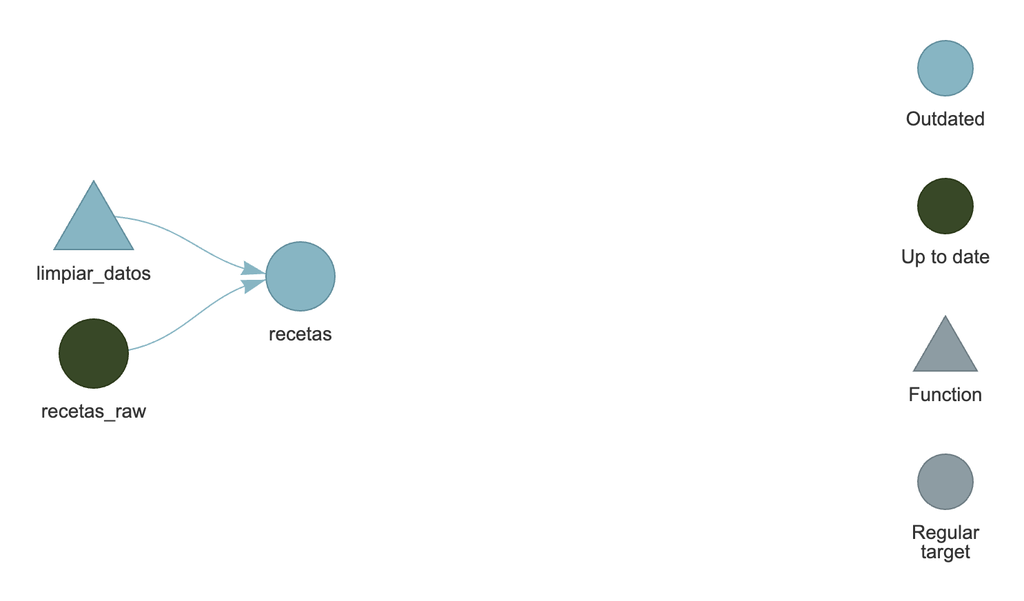

Gráfico de dependencias

Al correr `tar_make()` de nuevo, verás que solo el target `recetas` se vuelve a ejecutar, ya que modificamos la función que afecta a ese target.

Existen varias funciones que nos permiten tener un control más detallado sobre la ejecución del pipeline.

Por ejemplo, podemos forzar la reconstrucción de un target específico con `tar_invalidate()` o o ejecutar solo un target y sus dependencias con `tar_make(names = "target_name")`

```r
tar_invalidate(names = "recetas")
tar_make(recetas)
```

```
+ recetas dispatched
✔ recetas completed [5ms, 39.37 kB]
✔ ended pipeline [119ms, 1 completed, 1 skipped]
```

Con `tar_outdated()` identificamos targets desactualizados, mientras que `tar_destroy()` elimina todos los datos generados por el pipeline.

Puedes consultar esta y otras funciones en la documentación oficial de [`targets`](https://docs.ropensci.org/targets/index.html)

## Resumen

- Hemos creado un pipeline básico utilizando el paquete `targets`.
- Definimos targets para leer y limpiar un dataset de recetas.
- Ejecutamos el pipeline y accedimos a los resultados generados.
- Visualizamos y analizamos el flujo del pipeline y sus dependencias.
- El archivo `_targets.R` que hemos generado en esta notebook lo encuentras como: `_targets1.R`